# INFO201 Problem Set: Rmarkdown and plotting

Anika Razdan

2/17/2023

# 1 Load and Check data

**1. A new markdown file has been created with an appropriate title.**

**2. Load data.**

We have 13,055 rows and 25 columns.

**3. Print a small sample of the data.**

```
##   iso3  name iso2   region                      sub.region intermediate.region
## 1  ABW Aruba   AW Americas Latin America and the Caribbean           Caribbean
## 2  ABW Aruba   AW Americas Latin America and the Caribbean           Caribbean
## 3  ABW Aruba   AW Americas Latin America and the Caribbean           Caribbean
## 4  ABW Aruba   AW Americas Latin America and the Caribbean           Caribbean
## 5  ABW Aruba   AW Americas Latin America and the Caribbean           Caribbean
##   time totalPopulation fertilityRate lifeExpectancy childMortality
## 1 1960           54211         4.820         65.662             NA
## 2 1961           55438         4.655         66.074             NA
## 3 1962           56225         4.471         66.444             NA
## 4 1963           56695         4.271         66.787             NA
## 5 1964           57032         4.059         67.113             NA
##   youthFemaleLiteracy youthMaleLiteracy adultLiteracy GDP_PC accessElectricity
## 1                  NA                NA            NA     NA                NA
## 2                  NA                NA            NA     NA                NA
## 3                  NA                NA            NA     NA                NA
## 4                  NA                NA            NA     NA                NA
## 5                  NA                NA            NA     NA                NA
##   agriculturalLand agricultureTractors cerealProduction fertilizerHa      co2
## 1               NA                  NA               NA           NA 11092.67
## 2               20                  NA               NA           NA 11576.72
## 3               20                  NA               NA           NA 12713.49
## 4               20                  NA               NA           NA 12178.11
## 5               20                  NA               NA           NA 11840.74
##   greenhouseGases   co2_PC pm2.5_35 battleDeaths
## 1              NA 204.6204       NA           NA
## 2              NA 208.8228       NA           NA
## 3              NA 226.1181       NA           NA
## 4              NA 214.8004       NA           NA
## 5              NA 207.6158       NA           NA
```

# 2 Descriptive statistics

**1. How many countries are there in the dataset?**

There are 250 countries for *names*, 249 countries for *iso2*, and 253 countries for *iso3*.

# 3 CO2 emissions

**1. Analyze CO2 data**

```
## # A tibble: 61 × 3
##     time co2_na co2_PC_na
##    <int>  <int>     <int>
##  1  1960     60        60
##  2  1961     60        60
##  3  1962     58        58
##  4  1963     57        57
##  5  1964     51        51
##  6  1965     51        51
##  7  1966     51        51
##  8  1967     51        51
##  9  1968     51        51
## 10  1969     51        51
## 11  1970     50        50
## 12  1971     49        49
```

[output cut: 49 more lines]

The years 2017, 2018, and 2019 have the most missing data for *co2* and *co2_PC*.

**2. Plot total CO2 emissions over time for US, China, India, and countries of choice**

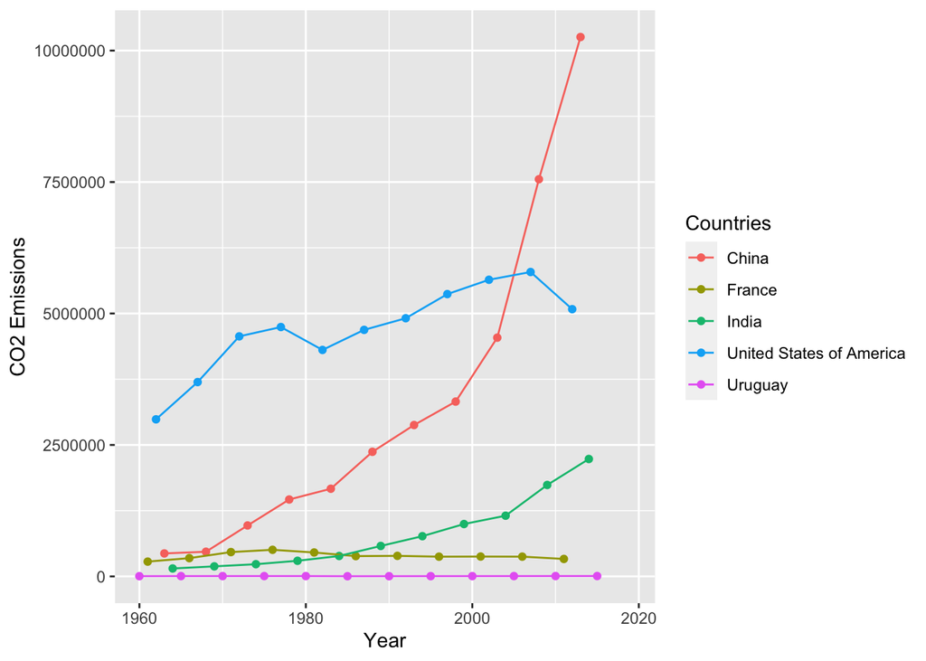

**3. Plot total CO2 emissions per capita over time for US, China, India, and countries of choice**

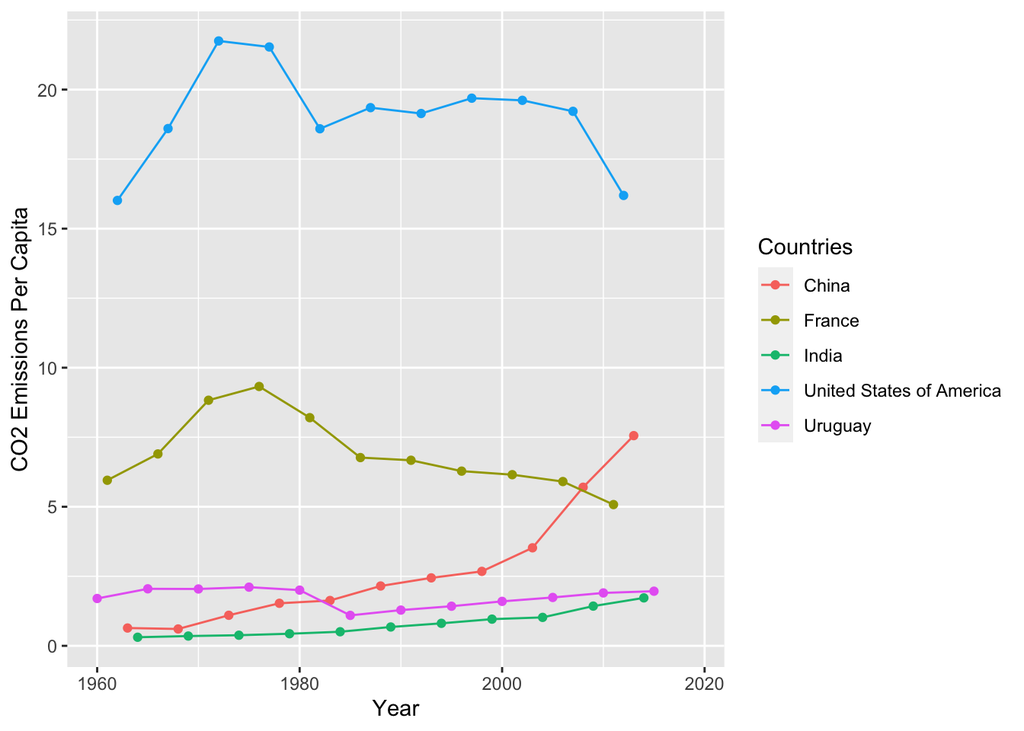

**4. Average CO2 emissions per capita across the continents**

```
## # A tibble: 305 × 3
## # Groups:   region [5]
##     region    time co2_PC_avg
##     <chr>    <int>      <dbl>
##   1 Africa    1960      0.291
##   2 Africa    1961      0.300
##   3 Africa    1962      0.299
##   4 Africa    1963      0.310
##   5 Africa    1964      0.349
##   6 Africa    1965      0.385
##   7 Africa    1966      0.422
##   8 Africa    1967      0.607
##   9 Africa    1968      0.781
##  10 Africa    1969      0.824
##  11 Africa    1970      0.844
```

[output cut: 294 more lines]

**5. Barplot for average CO2 emissions per capita across continents in 1960 and 2016**

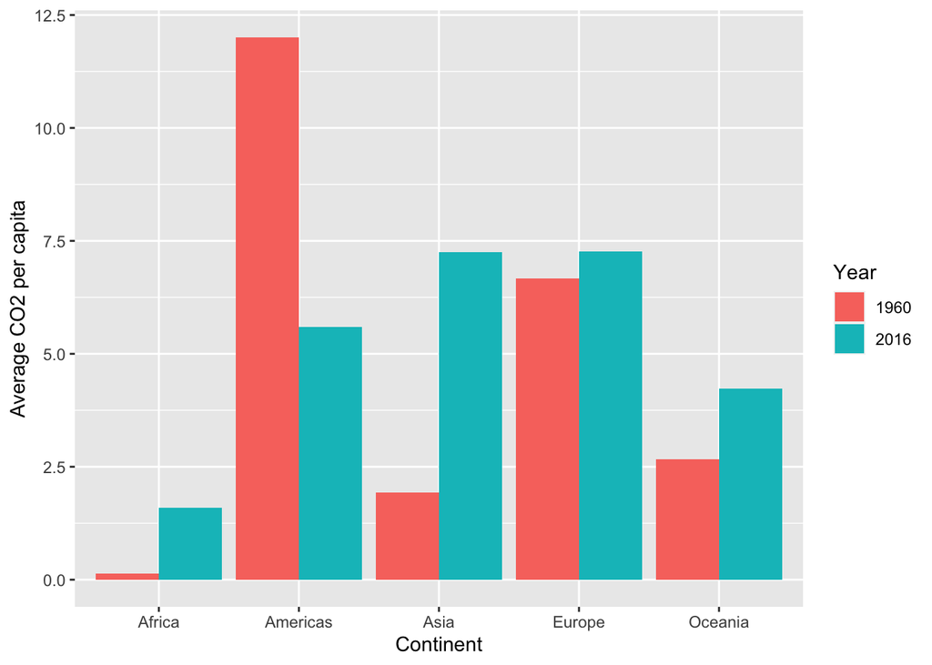

# 4 GDP per capita

**1. Scatterplot of GDP per capita vs. life expectancy by country in 1960**

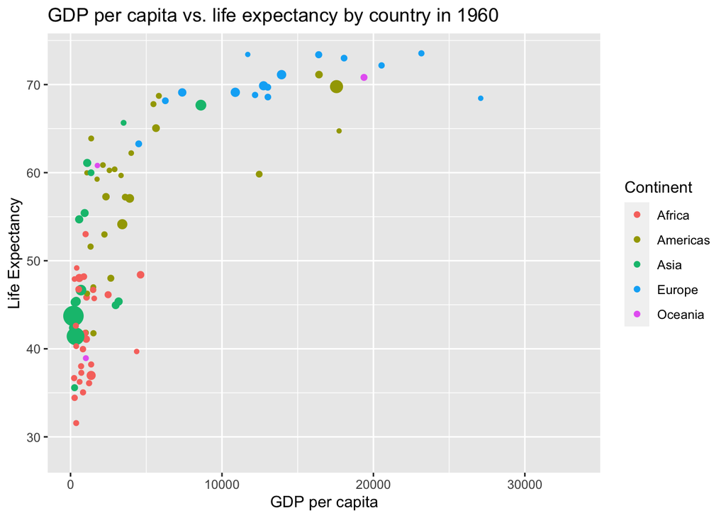

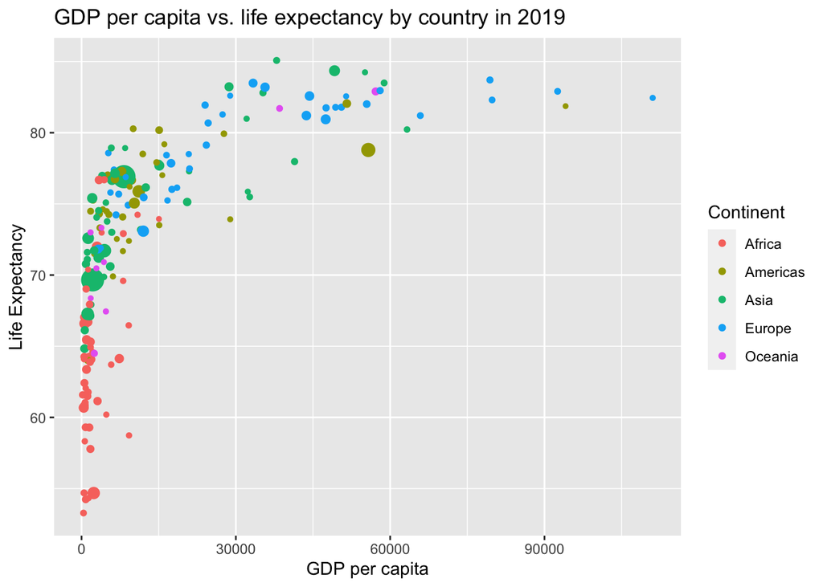

**3. Compare plots**

```
## # A tibble: 10 × 3
## # Groups:   region [5]
##    region    time lifeExpectancy_avg
##    <chr>    <int>              <dbl>
##  1 Africa    1960               41.4
##  2 Americas  1960               58.8
##  3 Asia      1960               53.2
##  4 Europe    1960               67.5
##  5 Oceania   1960               54.6
##  6 Africa    2016               63.4
##  7 Americas  2016               74.9
##  8 Asia      2016               73.3
##  9 Europe    2016               80.3
## 10 Oceania   2016               74.1
```

**5. Compute average LE growht frmo 1960-2019 across continents**

```
## # A tibble: 5 × 2
##   region   lifeExpectancy_growth_avg
##   <chr>                        <dbl>
## 1 Africa                      0.0438
## 2 Americas                    0.111
## 3 Asia                        0.0186
## 4 Europe                      0.0279
## 5 Oceania                     0.211
```

**6. Histogram of GDP per capita for years 1960 and 2019**

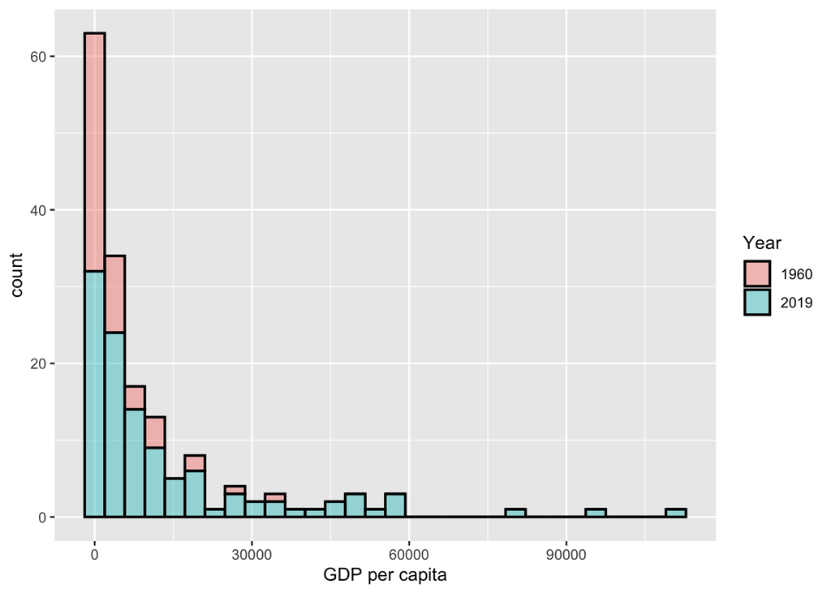

[figure not shown]

**7. Ranking of US in terms of life expectancy in 1960 and 2019**

```
##                       name rank
## 1 United States of America   17
```

```
##                       name rank
## 1 United States of America   46
```

**8. Relative rank**

```r
df %>% filter(time==1960 & name!="") %>%
  mutate(rank=rank(desc(lifeExpectancy))) %>% summarize(max_rank=max(rank))
```

```
##   max_rank
## 1      212
```